# Exploring Global Trends: A UNICEF Indicators Dashboard Story

Author

Sanjana Pal

Published

April 25, 2025

# 1 **Introduction**

In a world where economic and health disparities between countries are vast, understanding the intricate relationship between economic growth, public health, and military expenditure becomes crucial. This dashboard, powered by UNICEF’s global indicators, takes you on a journey through data, helping us explore these complex interactions and the trends shaping our future.

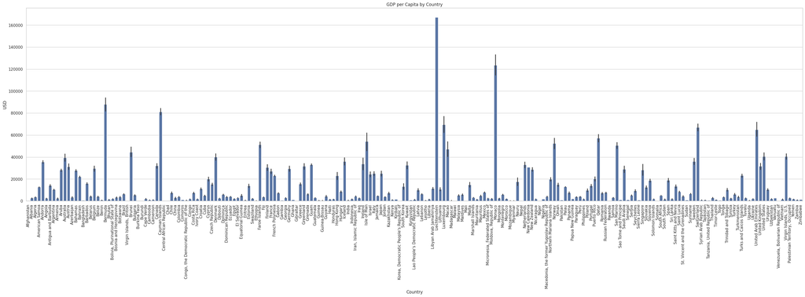

```python
import pandas as pd
import matplotlib.pyplot as plt
import plotly.express as px
import seaborn as sns
import geopandas as gpd
import plotnine as p9
import numpy as np

sns.set(style='whitegrid')
plt.rcParams['figure.figsize'] = (10, 6)

df = pd.read_csv("unicef_metadata.csv")

df['GDP_total'] = df['GDP_per_capita'] * df['total_Population']

sns.set(style='whitegrid')
plt.figure(figsize=(40, 10))
sns.barplot(x='country', y='GDP_per_capita', data=df)
plt.title('GDP per Capita by Country')
plt.ylabel('USD')
plt.xticks(rotation=90)
plt.xlabel('Country')
plt.show()
```

# 2 **Uncovering the Economic Landscape**

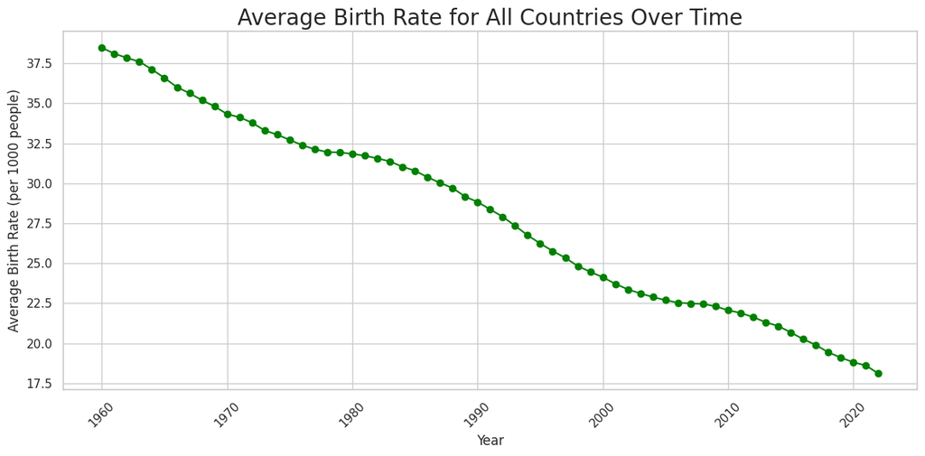

```python
# Group by year and calculate the average birth rate across all countries
avg_birth_rate_by_year = df.groupby('year')['Birth_rate'].mean()

# Plot the average birth rate over the years
plt.figure(figsize=(12, 6))
plt.plot(avg_birth_rate_by_year.index, avg_birth_rate_by_year, marker='o', linestyle='-', color='green')
plt.title('Average Birth Rate for All Countries Over Time', fontsize=20)
plt.xlabel('Year')
plt.ylabel('Average Birth Rate (per 1000 people)')
plt.grid(True)
plt.xticks(rotation=45)
plt.tight_layout()
plt.show()
```

# 3 **The Birth Rate Story: Global Trends**

Global birth rates reveal the shifting dynamics of societies. In developed countries like Japan, Germany, and Italy, birth rates are declining due to factors like high living costs, urbanization, and changing social norms. This decline creates challenges, including aging populations and labor shortages, which affect economic sustainability.

Meanwhile, emerging economies in Africa and Asia, such as India and Nigeria, experience higher birth rates, leading to rapid population growth. This strain on resources, including healthcare and education, is being addressed through economic development and improved access to family planning, gradually lowering birth rates.

The global trend is shifting, with some countries managing declining populations while others handle growth. As nations adjust, birth rates will continue to play a critical role in shaping economic and social policies, highlighting the need for balanced, sustainable development worldwide.

**Note**

Color Scale: Green line represents the world’s avg. birth rate.

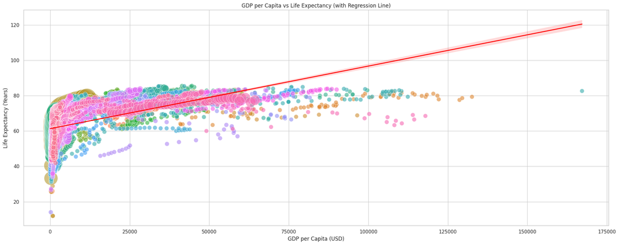

```python
# Ensure numeric conversion for regression
df = df.dropna(subset=['GDP_per_capita', 'Life_expectancy', 'total_Population'])
df['GDP_per_capita'] = pd.to_numeric(df['GDP_per_capita'], errors='coerce')
df['Life_expectancy'] = pd.to_numeric(df['Life_expectancy'], errors='coerce')
df['total_Population'] = pd.to_numeric(df['total_Population'], errors='coerce')

# Plot
plt.figure(figsize=(20, 8))

# Bubble scatter plot
sns.scatterplot(
    x='GDP_per_capita',
    y='Life_expectancy',
    size='total_Population',
    hue='country',
    data=df,
    sizes=(100, 2000),
    legend=False,
    alpha=0.6
)

# Regression line (no hue or size)
sns.regplot(
    x='GDP_per_capita',
    y='Life_expectancy',
    data=df,
    scatter=False,
    color='red',
    line_kws={'linewidth': 2}
)

plt.title('GDP per Capita vs Life Expectancy (with Regression Line)')
plt.xlabel('GDP per Capita (USD)')
plt.ylabel('Life Expectancy (Years)')
plt.grid(True)
plt.tight_layout()
plt.show()
```

# 4 **The Correlation: GDP vs Life Expectancy**

Next, we dive into a fascinating relationship: GDP vs Life Expectancy. Can a country’s wealth determine the health and longevity of its people? A scatter plot shows that wealthier nations tend to have higher life expectancy, but there are interesting outliers too—countries like Costa Rica, which has a modest GDP but impressive life expectancy. As we add population size to the equation with a bubble chart, the complexity deepens. A regression line emerges, suggesting that while wealth is a strong predictor of health, other factors like lifestyle, healthcare access, and social systems play a role too.

**Note**

Color Scale: Countries are represented via coloured bubbles.

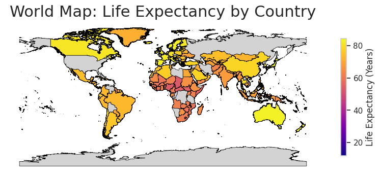

```python
# Load world map (country geometries)
world = gpd.read_file("https://raw.githubusercontent.com/datasets/geo-countries/master/data/countries.geojson")

metadata_df = df[['country', 'Life_expectancy']].dropna()

# Merge the metadata with the world map
# 'ADMIN' column in world contains country names
world_lifeexp = world.merge(metadata_df, left_on='name', right_on='country', how='left')

# Plotting
plt.figure(figsize=(18, 10))
world_lifeexp.plot(
    column='Life_expectancy',
    cmap='plasma',  # colorful scheme
    legend=True,
    legend_kwds={'label': "Life Expectancy (Years)", 'shrink': 0.5},
    missing_kwds={'color': 'lightgrey'},
    edgecolor='black',
    linewidth=0.5
)
plt.title('World Map: Life Expectancy by Country', fontsize=22)
plt.axis('off')
plt.show()
```

# 5 **A Global View: Life Expectancy Across the World**

Finally, we zoom out to a world map showing life expectancy across the globe. Countries like Japan and Switzerland shine in their high life expectancy, while sub-Saharan Africa faces challenges that drastically lower the average. The map not only provides a visual sense of disparity but also serves as a call to action for international cooperation and policy reform.

**Note**

# 6 **Conclusion**